# STAT 380 Midterm

Spring 2019

Thomas Schaeffer

Due: 03/01/2019 11:59PM

**Integrity statment.** The work submitted for this assessment is entirely my own. I have neither given or recieved unauthorized assistance during the assessment, and/or I will speak with Dr. Beckman privately if I am now aware or later become aware of any activity that may be in violation of academic integrity policies stated in the course syllabus or Penn State policy. I understand that the content of my completed exam may not be shared, used, or reproduced for any reason without expressed written permission of Dr. Matthew Beckman (mdb268@psu.edu).

# Front matter

```r
# always clean up R environment
rm(list = ls())
# load all packages here
library(tidyverse)
library(nycflights13)
library(mdsr)
library(lubridate)
library(e1071)
library(class)
# user-defined functions
# load data
data("flights")  # from nycflights13 package
NWC2013 <- read.csv("nycWeather2013.csv")
# set RNG seed (don't change this for the midterm)
set.seed(822)
```

# Part 1: Principal Components Analysis of JFK Weather Station

## 1.1 Data preparation

** Task 1.1.1 The data are “complete”, but have been coded in an unconventional way. Recode all use of `NA` as `0` in the NCDC data. **

```r
# Recoding 'NA' as '0' in the data
NWC2013clean <- NWC2013
  NWC2013clean[is.na(NWC2013clean)]<- 0
str(NWC2013clean)
```

```
'data.frame':   1095 obs. of  30 variables:
 $ STATION: Factor w/ 3 levels "USW00014732",..: 1 1 1 1 1 1 1 1 1 1 ...
 $ NAME   : Factor w/ 3 levels "JFK INTERNATIONAL AIRPORT, NY US",..: 2 2 2 2 2 2 2 2 2 2 ...
 $ DATE   : Factor w/ 365 levels "2013-01-01","2013-01-02",..: 1 2 3 4 5 6 7 8 9 10 ...
 $ AWND   : num  15.43 13.65 11.18 15.43 9.84 ...
 $ PGTM   : num  0 0 0 0 0 0 0 0 0 0 ...
 $ PRCP   : num  0 0 0 0 0 0 0 0 0 0 ...
 $ SNOW   : num  0 0 0 0 0 0 0 0 0 0 ...
 $ SNWD   : num  0 0 0 0 0 0 0 0 0 0 ...
 $ TAVG   : num  0 0 0 0 0 0 0 0 0 0 ...
 $ TMAX   : int  41 34 34 39 43 47 45 49 51 48 ...
 $ TMIN   : int  27 23 25 33 34 34 38 37 36 40 ...
 $ TSUN   : num  0 0 0 0 0 0 0 0 0 0 ...
 $ WDF2   : int  260 320 260 270 330 260 310 220 270 290 ...
 $ WDF5   : num  320 310 270 270 320 300 290 220 250 280 ...
```

[output cut: 16 more lines]

**Task 1.1.2 A few of the variables in the provided data cannot be used for any meaningful analysis because every entry is identical. Identify which variables they are, report a bullet list indicating the name and description of these variables, and then remove them from your data prior to analysis.**

- PGTM: Peak Gust Time
- TSUN: Total Sunshine for the Period
- WT05: Hail (may include small hail)
- WT06: Glaze or rime

```r
# Making variables null
NWC2013clean$PGTM <- NULL
NWC2013clean$TSUN <- NULL
NWC2013clean$WT05 <- NULL
NWC2013clean$WT06 <- NULL
```

## 1.2 Principal components analysis for JFK weather station

**Task 1.2.1 Perform principal components analysis on data from the JFK airport weather station (only). Standardize all variables prior to analysis.**

```r
# Keeping stations with JFK station id only
NWC2013JFK <-
  NWC2013clean %>%
  filter(STATION == "USW00094789")
# Removing first 3 variables in data frame to perform pca
NWC2013JFK <-
    NWC2013JFK[-c(1,2,3)]

# Performing PCA on Frame
NWC2013JFKpca <-
  NWC2013JFK %>%
  prcomp(scale = TRUE)
(-1) * NWC2013JFKpca$rotation[, 1:2] %>% round(2)
```

```
       PC1   PC2
AWND  0.26 -0.31
PRCP  0.05  0.10
SNOW  0.21  0.20
SNWD  0.16  0.14
TAVG -0.37 -0.01
TMAX -0.35  0.04
TMIN -0.34  0.08
WDF2  0.13 -0.35
WDF5  0.16 -0.35
WSF2  0.26 -0.32
WSF5  0.26 -0.33
WT01  0.07  0.10
WT02  0.09  0.21
WT03 -0.04  0.01
WT04  0.13  0.17
WT08 -0.02  0.03
WT09  0.17  0.18
WT13  0.26  0.31
WT14  0.14  0.24
WT15  0.06  0.04
WT16  0.24  0.26
WT18  0.25  0.14
WT22  0.18  0.15
```

**Task 1.2.2 Plot the proportion of variance explained by each principal component on a scree plot.**

```
Ignoring unknown parameters: type
```

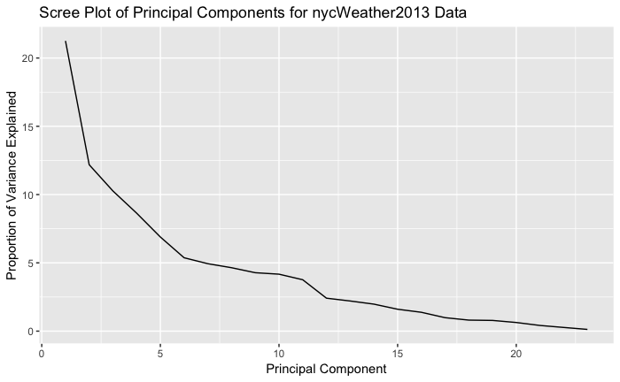

```r
# Creating new variables rowname, totalVar, pve, and cusum
NWC2013JFKpca_pve <-
  data.frame(sd = NWC2013JFKpca$sdev) %>%
  rownames_to_column() %>%
  mutate(rowname = parse_number(rowname),
         totalVar = sum(NWC2013JFKpca$sdev^2),
         pve = 100 * sd^2 / totalVar,
         cusum = cumsum(pve))
# Plotting scree plot
NWC2013JFKpca_pve %>%
  ggplot(aes(x = rowname, y = pve)) +
  geom_line(type = 3) +
  xlab("Principal Component") +
  ylab("Proportion of Variance Explained") +
  ggtitle("Scree Plot of Principal Components for nycWeather2013 Data")
```

```
Ignoring unknown parameters: type
```

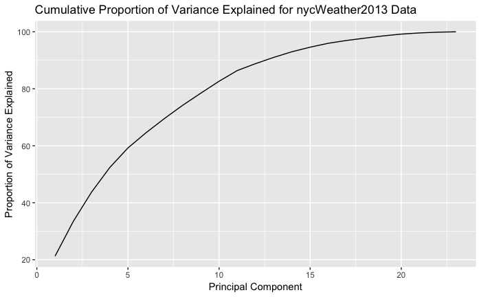

```r
# Plotting cumulative plot
NWC2013JFKpca_pve %>%
  ggplot(aes(x = rowname, y = cusum)) +
  geom_line(type = 3) +
  xlab("Principal Component") +
  ylab("Proportion of Variance Explained") +
  ggtitle("Cumulative Proportion of Variance Explained for nycWeather2013 Data")
```

**Task 1.2.3 How many principal components would be required to explain *at least* 76% of the variability in the JFK weather station data. Be sure to show your work.**

```r
# Filtering case where cusum is greater than 76%
NWC2013JFKpca_pve %>%
  filter(cusum >= 76)
```

| rowname | sd | totalVar | pve | cusum |
| --- | --- | --- | --- | --- |
| 9 | 0.9919683 | 23 | 4.2782653 | 78.46662 |
| 10 | 0.9793791 | 23 | 4.1703623 | 82.63698 |
| 11 | 0.9303379 | 23 | 3.7631680 | 86.40015 |
| 12 | 0.7450282 | 23 | 2.4133346 | 88.81348 |
| 13 | 0.7124518 | 23 | 2.2069027 | 91.02038 |
| 14 | 0.6742788 | 23 | 1.9767474 | 92.99713 |
| 15 | 0.6073099 | 23 | 1.6035881 | 94.60072 |
| 16 | 0.5633124 | 23 | 1.3796558 | 95.98038 |
| 17 | 0.4759971 | 23 | 0.9851012 | 96.96548 |
| 18 | 0.4308061 | 23 | 0.8069299 | 97.77241 |

[output cut: 5 more lines]

** It would require 9 principal components to explain at least 76% of the variability in the JFK weather station data. **

# Part 2: Predictive Modeling LaGuardia Flight Delays

## 2.1 Data preparation

Create `LaGuardiaFlights` data according to the following instructions:

1. Subset the `flights` data to include only the carriers that had at least 1000 flights depart from LaGuardia
   - call the resulting data frame `LaGuardiaFlights`
2. `LaGuardiaFlights` should include the following variables
   - `tenMinDelay`: **response** {TRUE / FALSE}; indicates departure delay greater than 10 minutes; remove cases with missing response
   - `hour`: hour of departure using 24 hr clock
   - `weekend`: {TRUE / FALSE} indicates flight departed on a Saturday or Sunday
   - `AWND`: average wind speed reported from the weather station at LaGuardia Airport
   - `PRCP`: precipitation reported from the weather station at LaGuardia Airport
   - `SNOW`: snowfall reported from the weather station at LaGuardia Airport
   - `fog`: {TRUE / FALSE} “Yes” if the weather station at LaGuardia Airport reported any of the following:
     - `WT22`: “Ice fog or freezing fog”
     - `WT01`: “Fog, ice fog, or freezing fog (may include heavy fog)”, or
     - `WT02`: “Heavy fog or heaving freezing fog (not always distinguished from fog”

```r
# Filter top 10 carriers
Top10 <-
  flights %>%
  filter(origin == "LGA") %>%
  group_by(carrier) %>%
  summarise(count = n()) %>%
  filter(count > 999) %>%
  arrange(desc(count))
# Assiginging top 10 carriers into a vector
TopCarriers <- c(Top10$carrier)
# Creating LGA only data frame
NWC2013cleanLGA <-
  NWC2013clean %>%
  filter(NAME == "LA GUARDIA AIRPORT, NY US") %>%
  mutate(DATE = as_date(DATE))

# Combing two data tables
LaGuardiaFlights <-
  flights %>%
  mutate(DATE = as_date(time_hour)) %>%
  left_join(NWC2013cleanLGA, "DATE")
# Creating new variables in LaGuardia Flights, filtering out certain cases that aren't from LaGuardia Airport, and selecting certain variables
LaGuardiaFlights <-
  LaGuardiaFlights %>%
  mutate(tenMinDelay = dep_delay >= 10,
         weekday = wday(time_hour),
         weekend = weekday %in% c(1,7),
         fog = ifelse(WT22 == 1 | WT01 == 1 | WT02 == 1, TRUE, FALSE)) %>%
  filter(carrier %in% TopCarriers,
         origin == "LGA",
         !is.na(dep_delay)) %>%
  select(tenMinDelay, hour, weekend, AWND, PRCP, SNOW, fog)
# Show finished LaGuardiaFlights
LaGuardiaFlights
```

| tenMinDelay | hour | weekend | AWND | PRCP | SNOW | fog |
| --- | --- | --- | --- | --- | --- | --- |
| FALSE | 5 | FALSE | 15.43 | 0 | 0 | FALSE |
| FALSE | 6 | FALSE | 15.43 | 0 | 0 | FALSE |
| FALSE | 6 | FALSE | 15.43 | 0 | 0 | FALSE |
| FALSE | 6 | FALSE | 15.43 | 0 | 0 | FALSE |
| FALSE | 6 | FALSE | 15.43 | 0 | 0 | FALSE |
| FALSE | 6 | FALSE | 15.43 | 0 | 0 | FALSE |
| FALSE | 6 | FALSE | 15.43 | 0 | 0 | FALSE |
| FALSE | 6 | FALSE | 15.43 | 0 | 0 | FALSE |
| FALSE | 6 | FALSE | 15.43 | 0 | 0 | FALSE |
| TRUE | 6 | FALSE | 15.43 | 0 | 0 | FALSE |

[output cut: 990 more lines]

**Task 2.1.1 How many total cases are in the `Training` set?**

```r
# Finding total training cases
n <- nrow(LaGuardiaFlights)
test_idx <- sample.int(n, size = round(0.25 * n))
train <- LaGuardiaFlights[-test_idx, ]
nrow(train)
```

```
[1] 75194
```

**Task 2.1.2 What percentage of these flights departed at least 10 minutes late?**

```r
# Finding numbers of flights departed at least 10 minutes late
LGFTMD <-
  LaGuardiaFlights %>%
  filter(tenMinDelay == "TRUE") %>%
  nrow
# Finding percentage
LGFTMD / nrow(LaGuardiaFlights) *100
```

```
[1] 22.59648
```

**Task 2.1.3 What percentage of these flights departed on the “Weekend”?**

```r
# Finding number of flights departed on the weekend
LGFWND <-
  LaGuardiaFlights %>%
  filter(weekend == "TRUE") %>%
  nrow()
# Finding percentage
LGFWND / nrow(LaGuardiaFlights) *100
```

```
[1] 23.49814
```

**Task 2.1.4 What percentage of these flights departed on a day with “Fog”?**

```r
# Finding number of flights departing with fog
LGFFOG <-
  LaGuardiaFlights %>%
  filter(fog == "TRUE") %>%
  nrow
# Finding percentage
LGFFOG / nrow(LaGuardiaFlights) *100
```

```
[1] 13.30454
```

## 2.2 Partition test and training data

**Task 2.2.1 partition 20% of the `LaGuardiaFlights` data for `Test` data and use the remaining 80% for `Training` data (Note: make sure `set.seed(822)` is properly specified in the Front Matter of your Rmd document)**

```r
# Creating train data
n <- nrow(LaGuardiaFlights)
test_idx <- sample.int(n, size = round(0.2 * n))
train <- LaGuardiaFlights[-test_idx, ]
nrow(train)
```

```
[1] 80207
```

```r
# Creating test data
test <- LaGuardiaFlights[test_idx, ]
nrow(test)
```

```
[1] 20052
```

## 2.3 Predictive modeling

**Task 2.3.1 Fit a null model to the `Training` data, and report the accuracy of the model.**

```r
# Creating null model
mod_null <- tally(~ tenMinDelay, data = train, format = "percent")
mod_null
```

```
tenMinDelay
    TRUE    FALSE
22.61897 77.38103
```

**Task 2.3.2 Fit a logistic regression model to the `Training` data. Show the resulting confusion matrix, and report the accuracy of the model.**

```r
# Creating logistic model
mod_logit <- glm(tenMinDelay ~ ., data = train, family = "binomial")
msummary(mod_logit)
```

```
Coefficients:
             Estimate Std. Error z value Pr(>|z|)
(Intercept) -3.298646   0.040207 -82.042  < 2e-16 ***
hour         0.139011   0.002069  67.173  < 2e-16 ***
weekendTRUE -0.340572   0.022009 -15.474  < 2e-16 ***
AWND         0.011292   0.002413   4.680 2.87e-06 ***
PRCP         0.813296   0.029104  27.944  < 2e-16 ***
SNOW         0.234974   0.018466  12.725  < 2e-16 ***
fogTRUE      0.252646   0.026851   9.409  < 2e-16 ***

(Dispersion parameter for binomial family taken to be 1)

    Null deviance: 85762  on 80206  degrees of freedom
Residual deviance: 79027  on 80200  degrees of freedom
AIC: 79041

Number of Fisher Scoring iterations: 4
```

```r
# Confusion matrix for logistic model
tenMinDelay_logitProb <- predict(mod_logit, newdata = train, type = "response")
tenMinDelay_logit <- ifelse(tenMinDelay_logitProb > 0.5, yes = "FALSE", "TRUE")
confusion <- tally(tenMinDelay_logit ~ tenMinDelay, data = train, format = "count")
confusion
```

```
                 tenMinDelay
tenMinDelay_logit  TRUE FALSE
            FALSE  1252   824
            TRUE  16890 61241
```

```r
# Model accuaracy for logistic model
logit_acc <- sum(diag(confusion)) / nrow(train) * 100
logit_acc
```

```
[1] 77.91465
```

**Task 2.3.3 Fit a *k*-nearest neighbors model to the `Training` data. Show the resulting confusion matrix, and report the accuracy of the model.**

```r
# Creating train quantile
train_quant <-
  train %>%
  select(hour, AWND, PRCP, SNOW)
# KNN classifier
tenMinDelay_knn <- knn(train = train_quant, test = train_quant, cl = train$tenMinDelay, k = 5)
# confusion matrix
confusion <- tally(tenMinDelay_knn ~ tenMinDelay, data = train, format = "count")
confusion
```

```
               tenMinDelay
tenMinDelay_knn  TRUE FALSE
          FALSE 13080 60058
          TRUE   5062  2007
```

```r
# Model accuracy for KNN
knn_acc <- (5072 + 60059) / nrow(train) * 100
knn_acc
```

```
[1] 81.20364
```

**Task 2.3.4 Fit a naive Bayes model to the `Training` data. Show the resulting confusion matrix, and report the accuracy of the model.**

```r
# Creating Naive Bayes
mod_nb <- naiveBayes(tenMinDelay ~ ., data = train)
tenMinDelay_nb <- predict(mod_nb, newdata = train)
confusion <- tally(tenMinDelay_nb ~ tenMinDelay, data = train, format = "count")
confusion
```

```
              tenMinDelay
tenMinDelay_nb  TRUE FALSE
         TRUE   2200  2401
         FALSE 15942 59664
```

```r
# Model accuracy for Naive Bayes
nb_acc <- sum(diag(confusion)) / nrow(train) * 100
nb_acc
```

```
[1] 77.13043
```

## 2.4 Visualization

** Task 2.4.1 Create a visualization that shows the predicted probability of 10 minute delay based on hour of departure and precipitation using a logistic regression classifier. Specifically,**

- The predicted probability of 10 minute delay should be clearly displayed for all plausible combinations of hour and precipitation.
- overlay `Test` data with clear indication of the observed response
- demonstrate good plotting practices

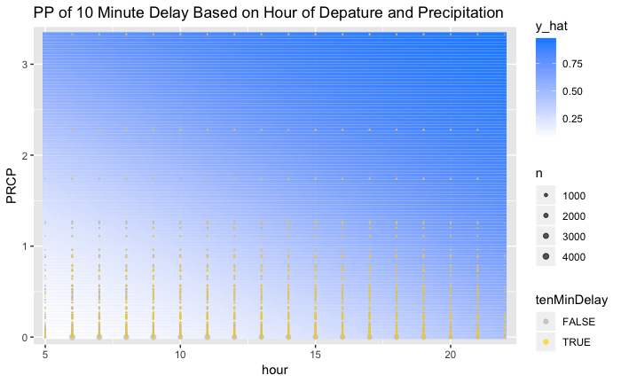

```r
train_logit <- glm(tenMinDelay ~ hour + PRCP, data = train, family = "binomial")
# Creating logistic model and probability of model
hours <- range(~ hour, data = train)
PRCPs <- range(~ PRCP, data = train)
res <- 100
fake_grid <-
  expand.grid(hour = seq(from = hours[1], to = hours[2], length.out = res),
              PRCP = seq(from = PRCPs[1], to = PRCPs[2], length.out = res))
train_logit_prob <-
  predict(train_logit, newdata = fake_grid, type = "response")
newdata <-
  fake_grid %>%
  mutate(y_hat = train_logit_prob)

# Creating plot
ggplot(data = newdata, aes(x = hour, y = PRCP)) +
  geom_tile(aes(fill = y_hat), color = NA) +
  geom_count(aes(color = tenMinDelay), alpha = 0.4, data = train) +
  geom_count(aes(color = tenMinDelay), alpha = 0.4, data = test) +
  scale_fill_gradient(low = "white", high = "dodgerblue") +
  scale_color_manual(values = c("gray", "gold")) +
  scale_size(range = c(0, 2)) +
  scale_x_continuous(expand = c(0.02,0)) +
  scale_y_continuous(expand = c(0.02,0)) +
  ggtitle("PP of 10 Minute Delay Based on Hour of Depature and Precipitation")
```